# Bubble Sort

Algoritma pengurutan yang pertama adalah Bubble Sort. Algoritma ini dikenal sebagai algoritma pengurutan yang membutuhkan waktu paling lama, hanya saja algoritma ini adalah algoritma pengurutan yang paling sederhana.

Bubble sort mengurutkan data dengan cara sebagai berikut :

1. data dibaca mulai dari paling kiri atau mulai dari indeks ke 0 (phyton) dari suatu list data
2. Bandingkan antara dua buah data yang saling berdekatan (antara data ke i dan i+1), tukar posisi jika data ke-i lebih besar dibandingkan data ke-i+1 (pengurutan secara ascending)
3. pindah satu posisi
4. lakukan perbandingan seperti langkah ke-2 dan pindah satu posisi kembali seperti langkah ke-3. Lakukan terus menerus sampai indeks data terakhir.
5. Setelah langkah ke-4 dilakukan, maka data yang berada di posisi paling kanan (indeks ke-N) adalah data terbesar .
6. Ulangi lagi langkah 1-4 dimulai dari indeks data ke 0 sampai dengan indeks ke N-1, N-2, ..., 0

Setiap iterasi berakhir, data yang terletak di posisi paling kanan adalah data yang paling besar, oleh karena itu algoritma ini disebut dengan 'bubble' karena data terbesar disetiap iterasi berakhir bergerak keatas seperti halnya gelembung. Berikut ilustrasi algoritma bubble sort pada tiap iterasi. Misalkan terdapat data [7, 2.5, 5. 10, 1].

Iterasi Kertama, bertujuan untuk memindahkan data terbesar, yaitu 10, ke posisi terakhir atau paling kanan dari list (karena proses pengurutan secara ascending (dari kecil-ke besar). Proses iterasi pertama ini dapat dilihat pada Gambar 1.

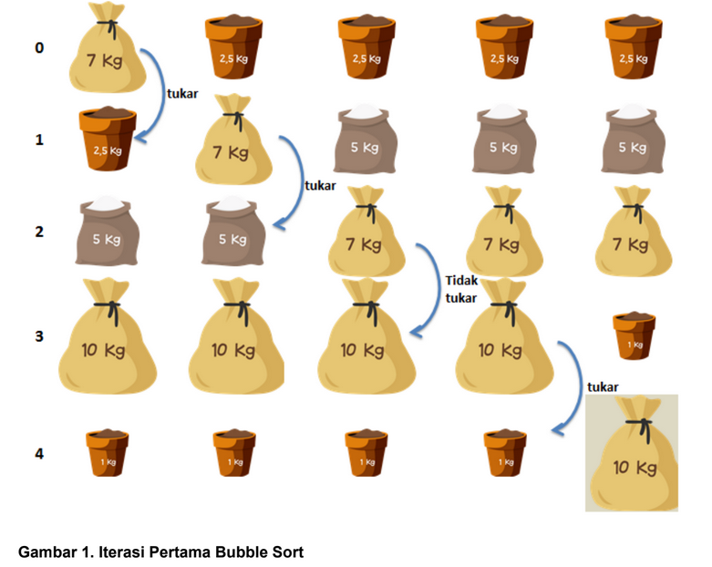

Iterasi Kedua, bertujuan untuk memindahkan data terbesar kedua, yaitu 7, agar menempati posisi tepat sebelum data 10, seperti yang terlihat pada Gambar 2.

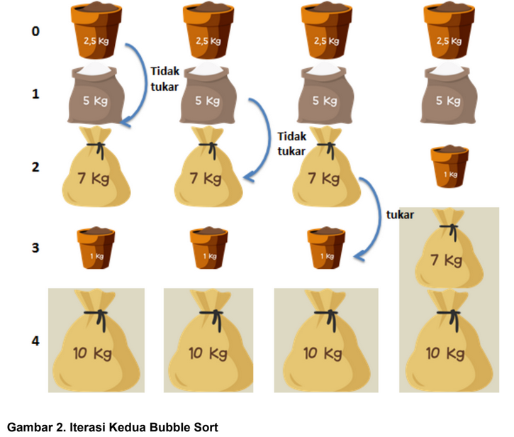

Iterasi Ketiga, bertujuan untuk memindahkan data terbesar ketiga, yaitu 5, untuk menempati posisi tepat sebelum data 7, seperti yang ditunjukkan pada Gambar 3.

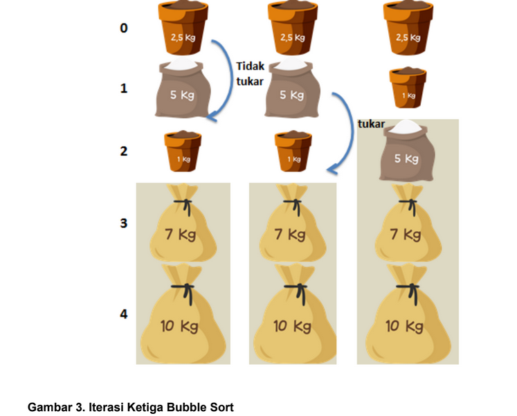

Proses ini dilakukan terus menerus sampai tidak ada data lagi yang akan dibandingkan. Data dalam keadaan terurut, dapat dilihat pada Gambar 4.

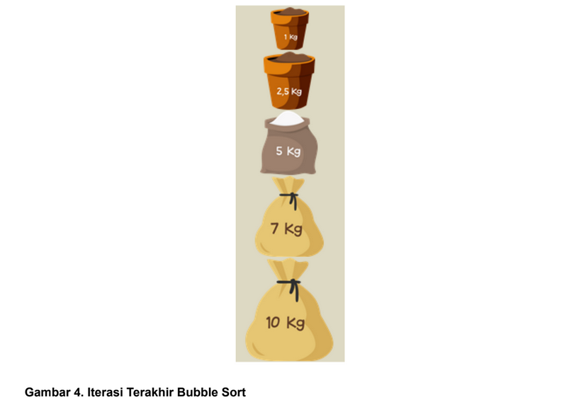

### Code

```python
def bubbleSort(listData):
    print('Data yang akan diurutkan : ', listData)
    count=0
    for outIter in range(len(listData)-1,-1,-1):
        print('outIter=',outIter)
        count=count+1
        print ('Iterasi ke-', count,':')
        for i in range(outIter):
            if listData[i]>listData[i+1]:
                temp=listData[i]
                listData[i]=listData[i+1]
                listData[i+1]=temp
                listData[i],listData[i+1]=listData[i+1],listData[i]
            print(outIter,'=',listData)
    print('Data urut-',listData)


data = [4,3,2,1]
bubbleSort(data)
```

```
Data yang akan diurutkan :  [4, 3, 2, 1]
outIter= 3
Iterasi ke- 1 :
3 = [4, 3, 2, 1]
3 = [4, 3, 2, 1]
3 = [4, 3, 2, 1]
outIter= 2
Iterasi ke- 2 :
2 = [4, 3, 2, 1]
2 = [4, 3, 2, 1]
outIter= 1
Iterasi ke- 3 :
1 = [4, 3, 2, 1]
outIter= 0
Iterasi ke- 4 :
Data urut- [4, 3, 2, 1]
```

```python
def bubbleSort(listData):
    print('Data yang akan diurutkan : ', listData)
    count=0
    for outIter in range(len(listData)-1,-1,-1):
        print('outIter=',outIter)
        count=count+1
        print ('Iterasi ke-', count,':')
        for i in range(outIter-1,-1,-1):
            if listData[i]<listData[i+1]:
                # temp=listData[i]
                # listData[i]=listData[i+1]
                # listData[i+1]=temp
                listData[i],listData[i+1]=listData[i+1],listData[i]
            print(outIter,'=',listData)
    print('Data urut-',listData)


data = [12,0,5,1,11,20,4,2]
bubbleSort(data)
```

```
Data yang akan diurutkan :  [12, 0, 5, 1, 11, 20, 4, 2]
outIter= 7
Iterasi ke- 1 :
7 = [12, 0, 5, 1, 11, 20, 4, 2]
7 = [12, 0, 5, 1, 11, 20, 4, 2]
7 = [12, 0, 5, 1, 20, 11, 4, 2]
7 = [12, 0, 5, 20, 1, 11, 4, 2]
7 = [12, 0, 20, 5, 1, 11, 4, 2]
7 = [12, 20, 0, 5, 1, 11, 4, 2]
7 = [20, 12, 0, 5, 1, 11, 4, 2]
outIter= 6
Iterasi ke- 2 :
6 = [20, 12, 0, 5, 1, 11, 4, 2]
6 = [20, 12, 0, 5, 11, 1, 4, 2]
6 = [20, 12, 0, 11, 5, 1, 4, 2]
6 = [20, 12, 11, 0, 5, 1, 4, 2]
6 = [20, 12, 11, 0, 5, 1, 4, 2]
6 = [20, 12, 11, 0, 5, 1, 4, 2]
outIter= 5
Iterasi ke- 3 :
5 = [20, 12, 11, 0, 5, 1, 4, 2]
5 = [20, 12, 11, 5, 0, 1, 4, 2]
5 = [20, 12, 11, 5, 0, 1, 4, 2]
5 = [20, 12, 11, 5, 0, 1, 4, 2]
5 = [20, 12, 11, 5, 0, 1, 4, 2]
outIter= 4
Iterasi ke- 4 :
4 = [20, 12, 11, 5, 0, 1, 4, 2]
4 = [20, 12, 11, 5, 0, 1, 4, 2]
4 = [20, 12, 11, 5, 0, 1, 4, 2]
4 = [20, 12, 11, 5, 0, 1, 4, 2]
outIter= 3
Iterasi ke- 5 :
3 = [20, 12, 11, 5, 0, 1, 4, 2]
3 = [20, 12, 11, 5, 0, 1, 4, 2]
3 = [20, 12, 11, 5, 0, 1, 4, 2]
outIter= 2
Iterasi ke- 6 :
2 = [20, 12, 11, 5, 0, 1, 4, 2]
2 = [20, 12, 11, 5, 0, 1, 4, 2]
outIter= 1
Iterasi ke- 7 :
1 = [20, 12, 11, 5, 0, 1, 4, 2]
outIter= 0
Iterasi ke- 8 :
Data urut- [20, 12, 11, 5, 0, 1, 4, 2]
```

# INSERTION SORT

### Algoritma Insertion Sort

Pada algoritma insertion sort, diasumsikan bahwa sebagian data sudah dalam keadaan terurut (pada posisi sebelah kiri dari data list), sehingga data berikutnya akan dibandingkan dengan data yang sudah dalam keadaan terurut ini, dan disisipkan (insertion) pada bagian data yang sudah terurut tersebut. Dengan konsep seperti ini, posisi sebelah kiri dari list data (sebelum ada data baru yang akan disisipkan), selalu dalam keadaan terurut.  
Berikut algoritma Insertion Sort :

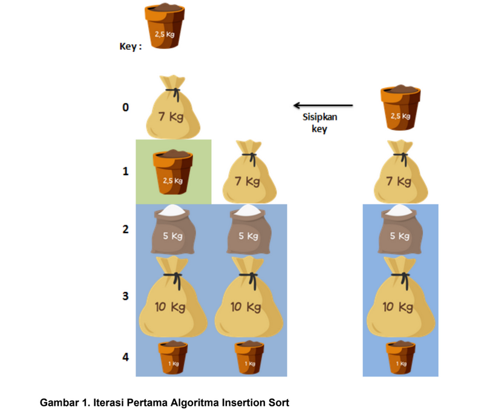

   Iterasi Kedua. Pada iterasi kedua menjadikan data pada indeks ke-2, yaitu 5, menjadi key. Sehingga pada iterasi kedua ini, berusaha menyispikan key pada kumpulan data terurut sebelumnya, yaitu [2.5, 7], dengan cara membandingkan satu persatu. Karena nilai key lebih kecil dari 7, dan lebih besar dari 2.5, maka key disisipkan diantara kedua nilai tersebut, sehingga data setelah iterasi kedua, menjadi [2.5, 5, 7, 10, 1]. Dapat dilihat bahwa data indeks ke-0, sampai dengan indeks ke-2, sudah dalam keadaan terurut. Ilustrasi ini dapat dilihat pada Gambar 2.

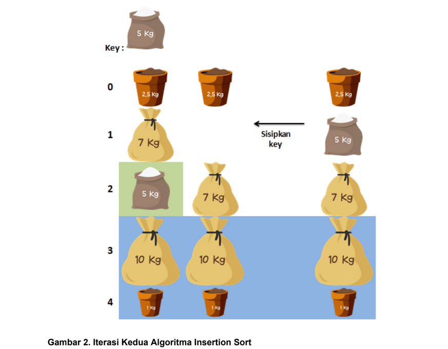

   Iterasi Ketiga. Key pada iterasi ketiga adalah data pada indeks ke-3, yaitu 10. Tujuan akhir dari iterasi ketiga adalah mencari lokasi yang tepat untuk data 10 diantara data yang sudah urut sebelumnya, yaitu [2.5, 5, 7]. Karena perbandingan pertama yang dilakukan adalah dengan data 7, dan 10 > 7, maka data 10 berada pada tempat yang sama. Ilustrasi iterasi ketiga ini, dapat dilihat pada Gambar 3.

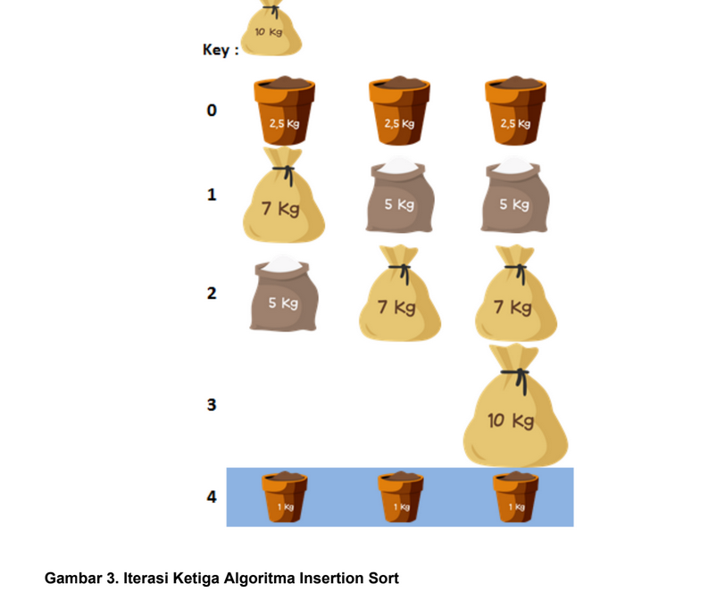

   Iterasi Keempat. Key untuk iterasi keempat adalah data pada indeks ke-4, yaitu 1. Pada iterasi keempat ini bertujuan untuk menyisipkan data 1 pada data yang sudah dalam keaadan urut sebelumnya, yaitu [2.5, 5, 7, 10]. Perbandingan dilakukan sebanyak empat kali untuk mencari posisi yang tepat untuk data 1 ini. Sehingga data 1 harus disisipkan, sebelum data 2.5. Ilustrasi ini dapat dilihat pada Gambar 4.

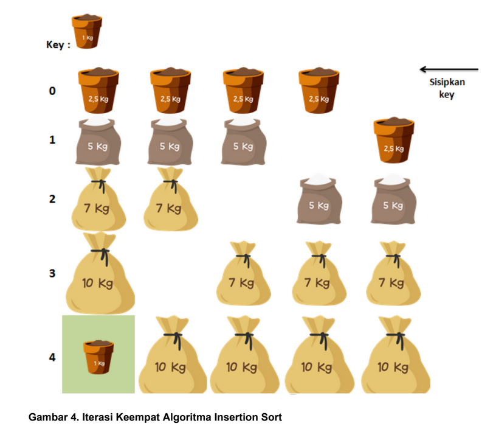

   Akhir dari iterasi keempat ini adalah data sudah dalam keaadan terurut, seperti yang ditunjukkan pada Gambar 5.

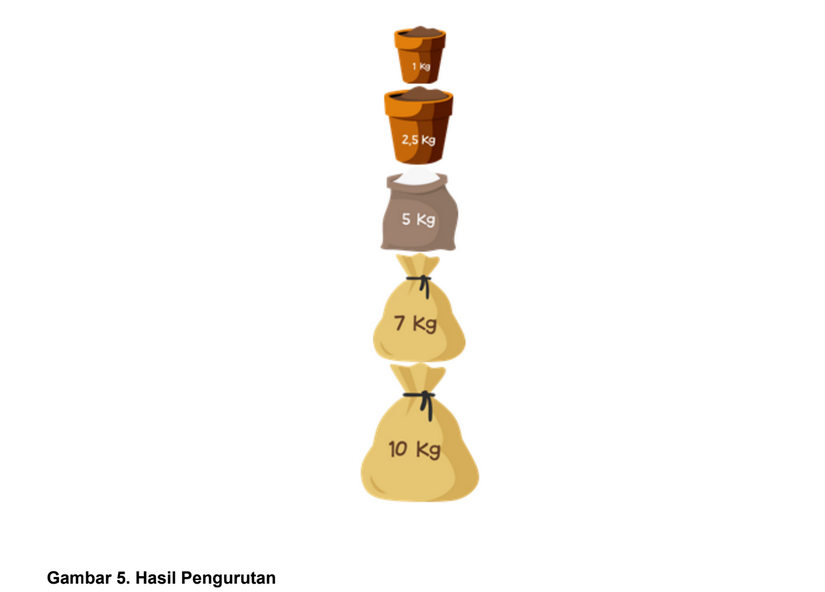

### Code

Berikut code untuk pengurutan dengan menggunakan algoritma Insertion Sort. Iterasi dalam, menggunakan iterasi while, karena iterasi akan berhenti atau tidak dikerjakan, ketika nilai pada key lebih dari data terakhir yang akan dibandingkan.

```python
def insertionSort(listData):
    for outIter in range(1,len(listData)):
        print(listData)
        key=listData[outIter]
        ind=outIter
        while (ind>0 and listData[ind-1]>key):
            listData[ind]=listData[ind-1]
            ind=ind-1
            print('inner=',listData)
        listData[ind]=key
    print('sortedData=',listData)
```

```python
b=[10,2,5,8,1,20,2,2,4]
insertionSort(b)
```

[output not shown]

```python
a = [10,2,5,8,1,20,2,2,4]

for i in range(1, len(a)):
    nilaiawal = a[i]
    hole = i
    while a[hole-1] > nilaiawal and hole > 0:
        a[hole] = a[hole-1]
        hole=hole-1

    a[hole] = nilaiawal
    print(a)
print('hasil = ',a)
```

[output not shown]

# SELECTION SORT

### Algoritma Selection Sort

Algoritma selection sort memiliki waktu komputasi yang lebih cepat dibandingkan dengan algoritma bubble sort. Hal ini dikarenakan terjadi reduksi waktu pada saat proses pertukaran data. Jika algoritma bubble sort, pada setiap iterasi,setiap dua data yang berdekatan akan dibandingkan, dan akan dilakukan pertukaran data jika syarat memenuhi. Maka pada algoritma selection sort tidak akan melakukan dua proses ini (perbandingan dan pertukaran) pada satu waktu, akan tetapi, pada algoritma selection sort, akan dicari data yang memenuhi syarat terlebih dahulu (perbandingan data), kemudian data yang terpilih ini ini akan diletakkan pada indeks data yang tepat. Oleh karena itu algoritma ini dinamakan selection (pemilihan data).  
Berikut tahapan algoritma selection sort (ascending order):

1. Algoritma ini dimulai dari indeks awal sampai dengan indeks akhir data
2. Cari data dengan nilai paling minimal (dari indeks awal sampai dengan indeks akhir) melalui proses perbandingan
3. Letakkan data minimal ini di indeks awal
4. Ulangi lagi proses pencarian data paling minimal (dari indeks awal+1 sampai dengan indeks akhir, karena indeks awal sudah terisi data yang tepat).
5. Letakkan data ini pada indeks awal+1
6. Ulangi lagi proses pencarian data paling minimal (dari indeks awal+2 sampai dengan akhir) dan letakkan data ini pada indeks awal+2, dst.

Berikut ilustrasi algoritma selection sort ini. Misalkan terdapat suatu data, yaitu [7, 2.5, 5, 10, 1]. Maka proses pengurutan secara ascending (dari nilai kecil sampai dengna nilai besar) dengan menggunakan algoritma Selection Sort adalah sebagai berikut :  
Iterasi Pertama. Pada iterasi pertama ini, data yang memiliki nilai paling kecil, akan menempati posisi dengan indeks paling awal. Untuk mencari data dengan nilai paling kecil ini, dilakukan perbandingan sebagai berikut:

1. antara indeks ke-0 dengan ke-1, sehingga nilai terkecil saat ini adalah 2.5
2. antara indeks ke-1 dengan ke-2, nilai terkecil tetaplah 2.5
3. antara indeks ke-2 dengan ke-3, nilai terkecil tetaplah 2.5
4. antara indeks ke-3 dengan ke-4, didapatkan nilai terkecil adalah 1. Pada saat pencarian nilai terkecil ini tidak dilakukan proses pertukaran posisi (berbeda dengan a;goritma bubble sort). Setelah didapatkan nilai terkecil, maka nilai 1 ini akan ditukar dengan data pada posisi dengan indeks ke-0, sehingga setelah iterasi pertama berakhir, data 1, akan menempati indeks ke-0. Ilustrasi iterasi pertama ini dapat dilihat pada Gambar 1.

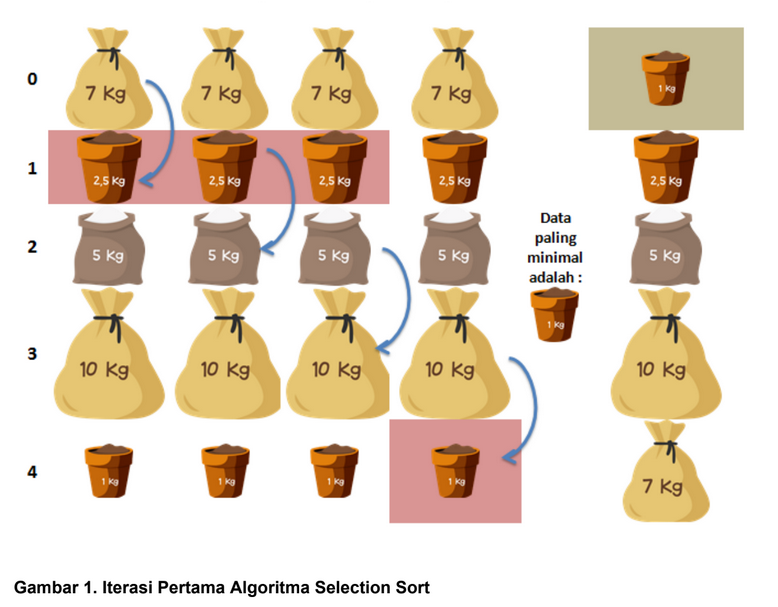

Iterasi Kedua. Pada iterasi kedua ini, data yang memiliki nilai paling kecil kedua, akan menempati posisi dengan indeks setelah data paling kecil, yaitu indeks ke-1. Untuk mencari data dengan nilai paling kecil kedua ini, dilakukan perbandingan, hanya saja data pada indeks ke-0 tidak perlu dibandingkan lagi, karena data pada indeks ke-0 sudah berisi data yang tepat. Perbandingan yang dilakukan untuk mencari nilai minimal kedua adalah sebagai berikut:

1. antara indeks ke-1 dengan ke-2, nilai terkecil tetaplah 2.5
2. antara indeks ke-2 dengan ke-3, nilai terkecil tetaplah 2.5
3. antara indeks ke-3 dengan ke-4, didapatkan nilai terkecil adalah 2.5 Setelah didapatkan nilai minimal, yaitu 2.5, maka nilai ini akan ditukar dengan data pada posisi dengan indeks ke-1, sehingga setelah iterasi kedua berakhir, data 2.5, akan menempati indeks ke-1. Ilustrasi iterasi kedua ini dapat dilihat pada Gambar 2.

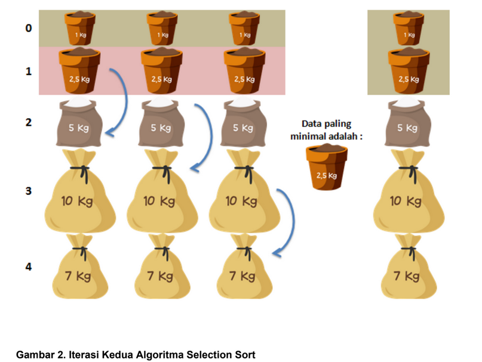

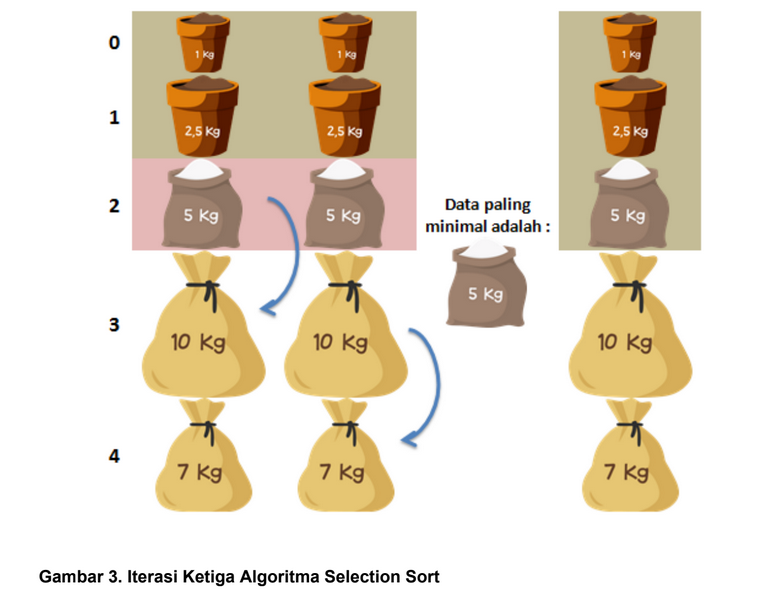

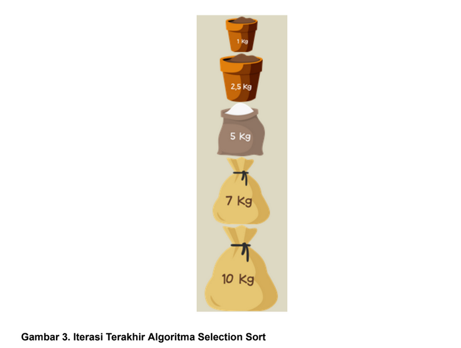

### Code

Berikut adalah code untuk algoritma selection sort, yang terdiri dari dua buah iterasi. Iterasi pertama digunakan untuk menempatkan data atau menukar data, sehingga data dengan nilai minimal, akan menempati indeks-indeks awal. Sedangkan iterasi kedua (iterasi dalam), digunakan untuk mencari nilai minimal.

```python
def selectionSort(listData):
    print('Algoritma Selection Sort konvensional')
    print('Data Awal=',listData)
    for outIter in range(len(listData)-1):
        minIndex=outIter
        for i in range(outIter+1,len(listData)):
            if listData[i]<listData[minIndex]:
                minIndex=i
        temp=listData[outIter]
        listData[outIter]=listData[minIndex]
        listData[minIndex]=temp
        print('Iterasi ke-',outIter+1,':',listData)
    print('Data Urut=',listData)
```

```python
a=[10,2,5,8,1,20,7,12,4]
selectionSort(a)
```

```
Algoritma Selection Sort konvensional
Data Awal= [10, 2, 5, 8, 1, 20, 7, 12, 4]
Iterasi ke- 1 : [1, 2, 5, 8, 10, 20, 7, 12, 4]
Iterasi ke- 2 : [1, 2, 5, 8, 10, 20, 7, 12, 4]
Iterasi ke- 3 : [1, 2, 4, 8, 10, 20, 7, 12, 5]
Iterasi ke- 4 : [1, 2, 4, 5, 10, 20, 7, 12, 8]
Iterasi ke- 5 : [1, 2, 4, 5, 7, 20, 10, 12, 8]
Iterasi ke- 6 : [1, 2, 4, 5, 7, 8, 10, 12, 20]
Iterasi ke- 7 : [1, 2, 4, 5, 7, 8, 10, 12, 20]
Iterasi ke- 8 : [1, 2, 4, 5, 7, 8, 10, 12, 20]
Data Urut= [1, 2, 4, 5, 7, 8, 10, 12, 20]
```